# Week Three Assignment - EDA with WDI

```r
df_yourdata |> filter(year == 2020) |>
  filter(region != "Aggregates") |>
  drop_na(short_name_1) |> arrange(short_name_1)
```

| country | iso2c | iso3c | year | status | lastupdated | short_name_1 | short_name_2 | region | capital | longitude | latitude | income | lending |
| --- | --- | --- | --- | --- | --- | --- | --- | --- | --- | --- | --- | --- | --- |
| Tanzania | TZ | TZA | 2020 | NA | 2023-12-18 | 30.62835 | 2552.5469 | Sub-Saharan Africa | Dodoma | 35.738200 | -6.174860 | Lower middle income | IDA |
| Mali | ML | MLI | 2020 | NA | 2023-12-18 | 35.36166 | 2123.8282 | Sub-Saharan Africa | Bamako | -7.500340 | 13.566700 | Low income | IDA |
| Mauritania | MR | MRT | 2020 | NA | 2023-12-18 | 35.88900 | 5236.4102 | Sub-Saharan Africa | Nouakchott | -15.982400 | 18.236700 | Lower middle income | IDA |
| Guinea | GN | GIN | 2020 | NA | 2023-12-18 | 37.39311 | 2604.1172 | Sub-Saharan Africa | Conakry | -13.700000 | 9.516670 | Lower middle income | IDA |
| Liberia | LR | LBR | 2020 | NA | 2023-12-18 | 37.80513 | 1383.8281 | Sub-Saharan Africa | Monrovia | -10.795700 | 6.300390 | Low income | IDA |
| Syrian Arab Republic | SY | SYR | 2020 | NA | 2023-12-18 | 37.92152 | NA | Middle East & North Africa | Damascus | 36.311900 | 33.514600 | Low income | IDA |
| Burkina Faso | BF | BFA | 2020 | NA | 2023-12-18 | 39.42958 | 2089.5678 | Sub-Saharan Africa | Ouagadougou | -1.533950 | 12.360500 | Low income | IDA |
| Mozambique | MZ | MOZ | 2020 | NA | 2023-12-18 | 41.29776 | 1237.9460 | Sub-Saharan Africa | Maputo | 32.571300 | -25.966400 | Low income | IDA |
| Djibouti | DJ | DJI | 2020 | NA | 2023-12-18 | 42.62564 | 4759.2590 | Middle East & North Africa | Djibouti | 43.142500 | 11.580600 | Lower middle income | IDA |
| Cameroon | CM | CMR | 2020 | NA | 2023-12-18 | 45.25903 | 3665.5106 | Sub-Saharan Africa | Yaounde | 11.517400 | 3.872100 | Lower middle income | Blend |

[output cut: 121 more lines]

**Observations and Questions:**

#### Ranking of the Indicator 2

```r
df_yourdata |> filter(year == 2020) |>
  filter(region != "Aggregates") |>
  drop_na(short_name_2) |> arrange(desc(short_name_2))
```

| country | iso2c | iso3c | year | status | lastupdated | short_name_1 | short_name_2 | region | capital | longitude | latitude | income | lending |
| --- | --- | --- | --- | --- | --- | --- | --- | --- | --- | --- | --- | --- | --- |
| Luxembourg | LU | LUX | 2020 | NA | 2023-12-18 | 107.18806 | 112274.8179 | Europe & Central Asia | Luxembourg | 6.129600 | 49.610000 | High income | Not classified |
| Singapore | SG | SGP | 2020 | NA | 2023-12-18 | 103.19959 | 94910.1014 | East Asia & Pacific | Singapore | 103.850000 | 1.289410 | High income | Not classified |
| Ireland | IE | IRL | 2020 | NA | 2023-12-18 | 135.22467 | 91791.4405 | Europe & Central Asia | Dublin | -6.267490 | 53.344100 | High income | Not classified |
| Qatar | QA | QAT | 2020 | NA | 2023-12-18 | 107.66615 | 89019.0699 | Middle East & North Africa | Doha | 51.508200 | 25.294800 | High income | Not classified |
| Bermuda | BM | BMU | 2020 | NA | 2023-12-18 | 80.44741 | 76117.8047 | North America | Hamilton | -64.706000 | 32.329300 | High income | Not classified |
| Switzerland | CH | CHE | 2020 | NA | 2023-12-18 | 104.21162 | 67928.1915 | Europe & Central Asia | Bern | 7.448210 | 46.948000 | High income | Not classified |
| United Arab Emirates | AE | ARE | 2020 | NA | 2023-12-18 | 120.35365 | 67668.2866 | Middle East & North Africa | Abu Dhabi | 54.370500 | 24.476400 | High income | Not classified |
| Cayman Islands | KY | CYM | 2020 | NA | 2023-12-18 | 97.39540 | 67530.6955 | Latin America & Caribbean | George Town | -81.385700 | 19.302200 | High income | Not classified |
| Norway | NO | NOR | 2020 | NA | 2023-12-18 | 119.94154 | 63776.1610 | Europe & Central Asia | Oslo | 10.738700 | 59.913800 | High income | Not classified |
| Brunei Darussalam | BN | BRN | 2020 | NA | 2023-12-18 | 88.43155 | 61603.5508 | East Asia & Pacific | Bandar Seri Begawan | 114.946000 | 4.941990 | High income | Not classified |

[output cut: 184 more lines]

**Observations and Questions:**

```r
df_yourdata |> filter(year == 2020) |>
  filter(region != "Aggregates") |>
  drop_na(short_name_2) |> arrange(short_name_2)
```

| country | iso2c | iso3c | year | status | lastupdated | short_name_1 | short_name_2 | region | capital | longitude | latitude | income | lending |
| --- | --- | --- | --- | --- | --- | --- | --- | --- | --- | --- | --- | --- | --- |
| Burundi | BI | BDI | 2020 | NA | 2023-12-18 | 46.39147 | 711.3553 | Sub-Saharan Africa | Bujumbura | 29.363900 | -3.378400 | Low income | IDA |
| Central African Republic | CF | CAF | 2020 | NA | 2023-12-18 | NA | 847.7650 | Sub-Saharan Africa | Bangui | 21.640700 | 5.630560 | Low income | IDA |
| Congo, Dem. Rep. | CD | COD | 2020 | NA | 2023-12-18 | NA | 1044.0712 | Sub-Saharan Africa | Kinshasa | 15.322200 | -4.325000 | Low income | IDA |
| Niger | NE | NER | 2020 | NA | 2023-12-18 | NA | 1214.5410 | Sub-Saharan Africa | Niamey | 2.107300 | 13.514000 | Low income | IDA |
| Mozambique | MZ | MOZ | 2020 | NA | 2023-12-18 | 41.29776 | 1237.9460 | Sub-Saharan Africa | Maputo | 32.571300 | -25.966400 | Low income | IDA |
| Liberia | LR | LBR | 2020 | NA | 2023-12-18 | 37.80513 | 1383.8281 | Sub-Saharan Africa | Monrovia | -10.795700 | 6.300390 | Low income | IDA |
| Madagascar | MG | MDG | 2020 | NA | 2023-12-18 | NA | 1436.2070 | Sub-Saharan Africa | Antananarivo | 45.716700 | -20.466700 | Low income | IDA |
| Somalia | SO | SOM | 2020 | NA | 2023-12-18 | NA | 1456.6559 | Sub-Saharan Africa | Mogadishu | 45.325400 | 2.075150 | Low income | IDA |
| Chad | TD | TCD | 2020 | NA | 2023-12-18 | NA | 1489.1867 | Sub-Saharan Africa | N'Djamena | 15.044500 | 12.104800 | Low income | IDA |
| Malawi | MW | MWI | 2020 | NA | 2023-12-18 | NA | 1489.6014 | Sub-Saharan Africa | Lilongwe | 33.770300 | -13.989900 | Low income | IDA |

[output cut: 184 more lines]

**Observations and Questions:**

### Histograms and Boxplots for Variation

Edit the title and year.

```r
INCOME <-c("Low income", "Lower middle income", "Upper middle income",
"High income")
```

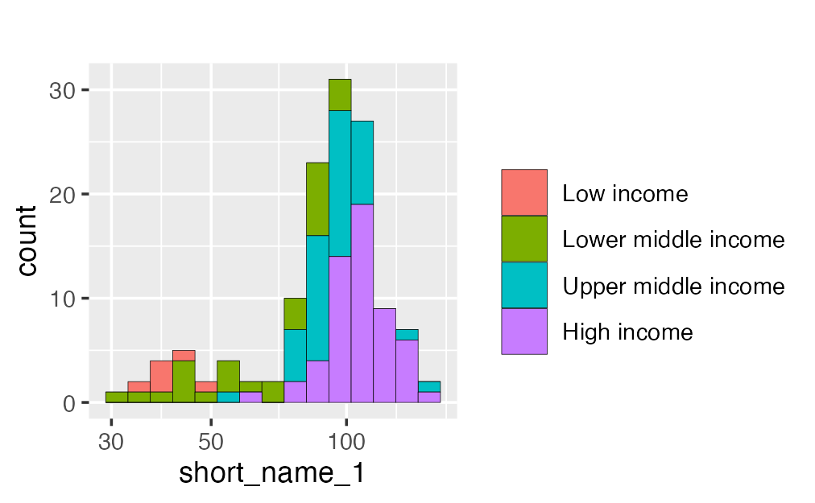

```r
df_yourdata |> filter(year == 2020) |>
  filter(region != "Aggregates") |>
  drop_na(short_name_1) |> filter(income != "Not classified") |>
  ggplot(aes(short_name_1, fill = factor(income, levels = INCOME))) + geom_histogram(bins = 15, col = "black", linewidth = 0.1) +
  scale_x_log10() +
  labs(title = "", fill = "")
```

**Observations and Questions:**

Edit the title and the years.

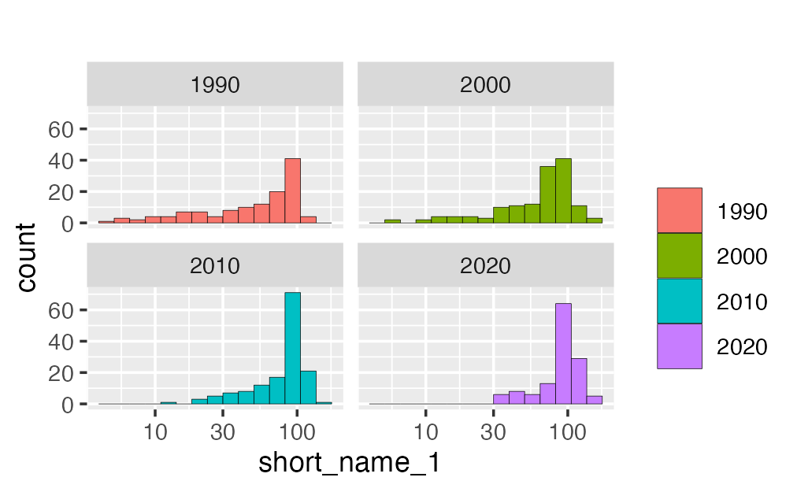

```r
df_yourdata |> filter(year %in% c(1990, 2000, 2010, 2020)) |> filter(region != "Aggregates") |>
  drop_na(short_name_1) |> filter(short_name_1 > 0) |> filter(income != "Not classified") |>
  ggplot(aes(short_name_1, fill = factor(year))) +
  geom_histogram(bins = 15, col = "black", linewidth = 0.1) +
  scale_x_log10() + facet_wrap(~year) +
  labs(title = "", fill = "")
```

**Observations and Questions:**

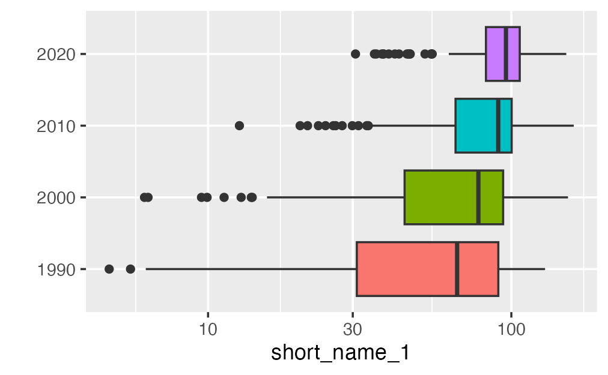

```r
df_yourdata |> filter(year %in% c(1990, 2000, 2010, 2020)) |> filter(region != "Aggregates") |>
  drop_na(short_name_1) |> filter(short_name_1 > 0) |> filter(income != "Not classified") |>
  ggplot(aes(short_name_1, factor(year), fill = factor(year))) +
  geom_boxplot() + scale_x_log10() + labs(y = "") + theme(legend.position = "none")
```

**Observations and Questions:**

Edit the title, and the year if necessary.

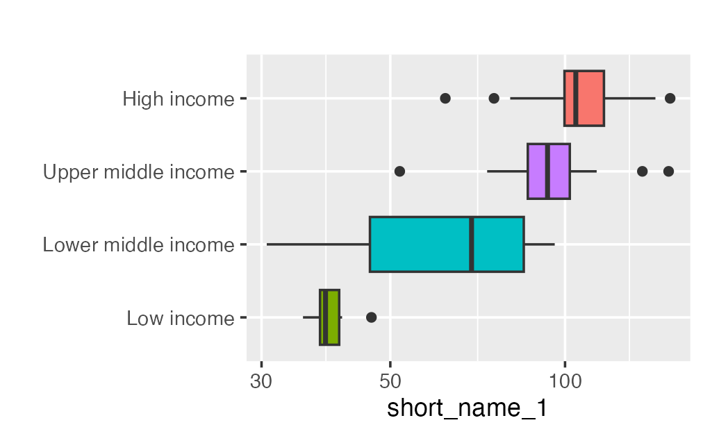

```r
df_yourdata |> filter(year == 2020) |> filter(region != "Aggregates") |>
  drop_na(short_name_1) |> filter(short_name_1 > 0) |> filter(income != "Not classified") |>
  ggplot(aes(short_name_1, factor(income, levels = INCOME), fill = income)) +
  geom_boxplot() + scale_x_log10() +
  labs(title = "", y = "", fill = "") +
  theme(legend.position = "none")
```

**Observations and Questions:**

Edit the title and year if necessary.

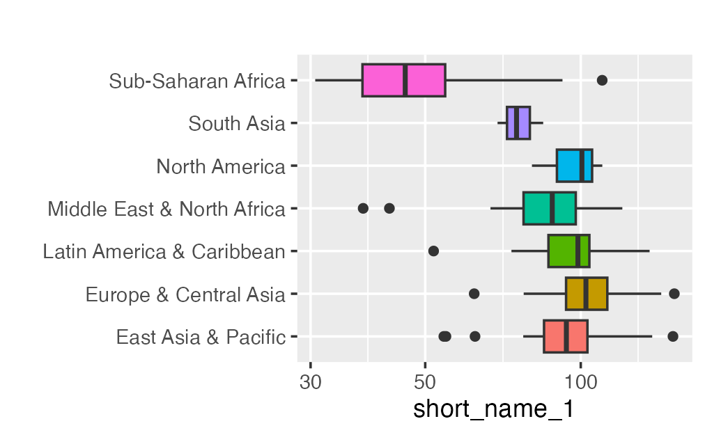

```r
df_yourdata |> filter(year == 2020) |> filter(region != "Aggregates") |>
  drop_na(short_name_1) |> filter(short_name_1 > 0) |>
  ggplot(aes(short_name_1, region, fill = region)) +
  geom_boxplot() + scale_x_log10() +
  labs(title = "", y = "", fill = "") +
  theme(legend.position = "none")
```

**Observations and Questions:**

#### GDP per capita

Edit the title, and year if necessary.

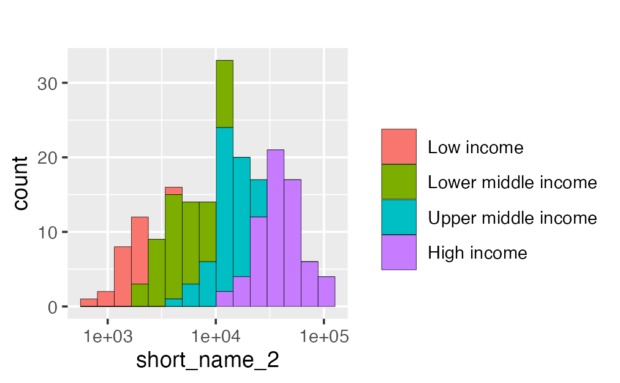

```r
df_yourdata |> filter(year == 2020) |> filter(region != "Aggregates") |>
  drop_na(short_name_2) |> filter(income != "Not classified") |>
  ggplot(aes(short_name_2, fill = factor(income, levels = INCOME))) + geom_histogram(bins = 15, col = "black", linewidth = 0.1) +
  scale_x_log10() +
  labs(title = "", fill = "")
```

Edit the title and the year if necessary.

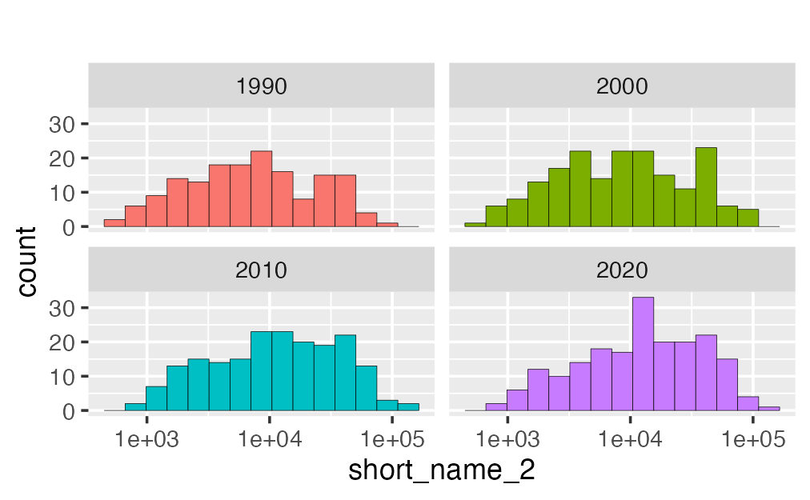

```r
df_yourdata |> filter(year %in% c(1990, 2000, 2010, 2020)) |> filter(region != "Aggregates") |>
  drop_na(short_name_2) |> filter(short_name_2 > 0) |> filter(income != "Not classified") |>
  ggplot(aes(short_name_2, fill = factor(year))) +
  geom_histogram(bins = 15, col = "black", linewidth = 0.1) +
  scale_x_log10() + facet_wrap(~year) +
  labs(title = "", fill = "") +
  theme(legend.position = "none")
```

**Observations and Questions:**

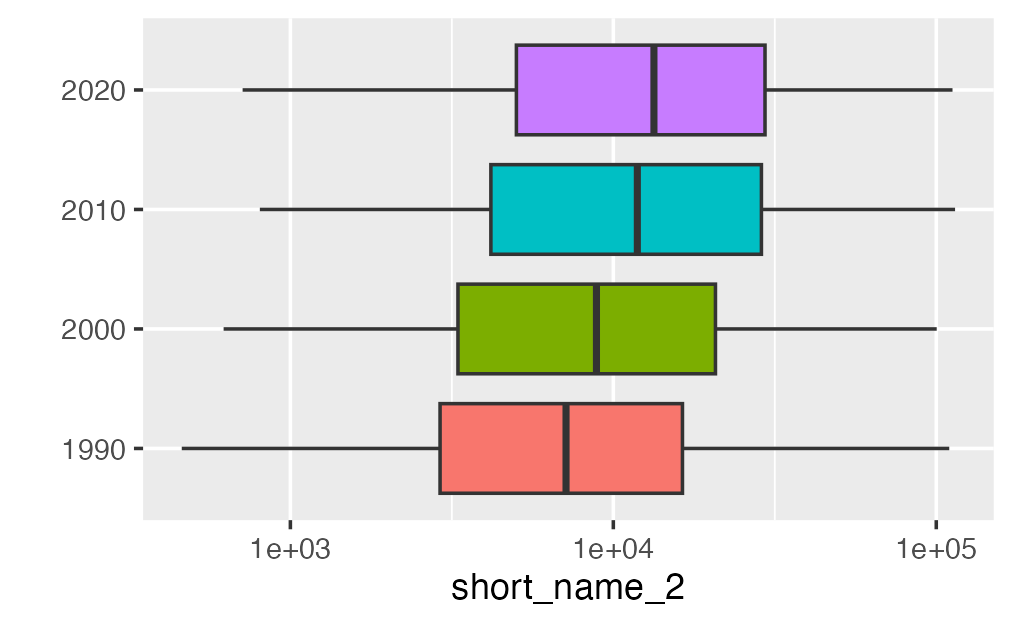

```r
df_yourdata |> filter(year %in% c(1990, 2000, 2010, 2020)) |> filter(region != "Aggregates") |>
  drop_na(short_name_2) |> filter(short_name_2 > 0) |> filter(income != "Not classified") |>
  ggplot(aes(short_name_2, factor(year), fill = factor(year))) +
  geom_boxplot() + scale_x_log10() + labs(y = "") + theme(legend.position = "none")
```

**Observations and Questions:**

Edit the title, and the year if necessary.

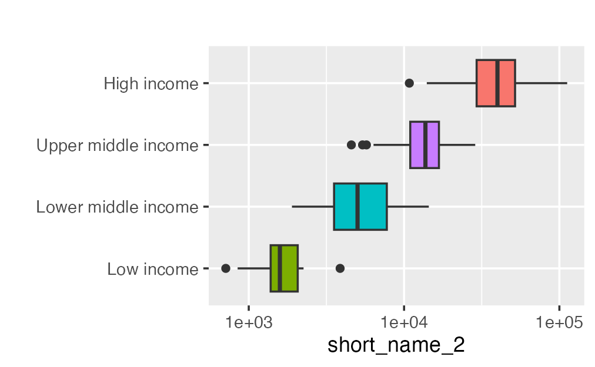

```r
df_yourdata |> filter(year == 2020) |> filter(region != "Aggregates") |>
  drop_na(short_name_2) |> filter(short_name_2 > 0) |> filter(income != "Not classified") |>
  ggplot(aes(short_name_2, factor(income, levels = INCOME), fill = income)) +
  geom_boxplot() + scale_x_log10() +
  labs(title = "", y = "", fill = "") +
  theme(legend.position = "none")
```

**Observations and Questions:**

Edit the title and the year if necessary.

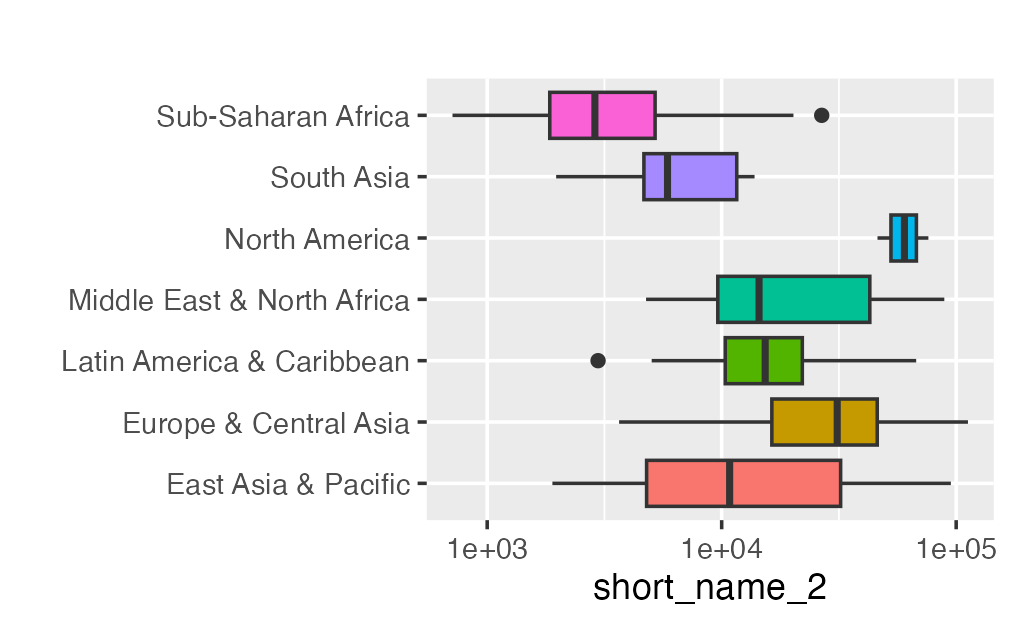

```r
df_yourdata |> filter(year == 2020) |> filter(region != "Aggregates") |>
  drop_na(short_name_2) |> filter(short_name_2 > 0) |>
  ggplot(aes(short_name_2, region, fill = region)) +
  geom_boxplot() + scale_x_log10() +
  labs(title = "", y = "", fill = "") +
  theme(legend.position = "none")
```

### Scatterplot for Covariation

#### Scatterplot with a regression line

Edit the title, the labels of x- and y- axes.

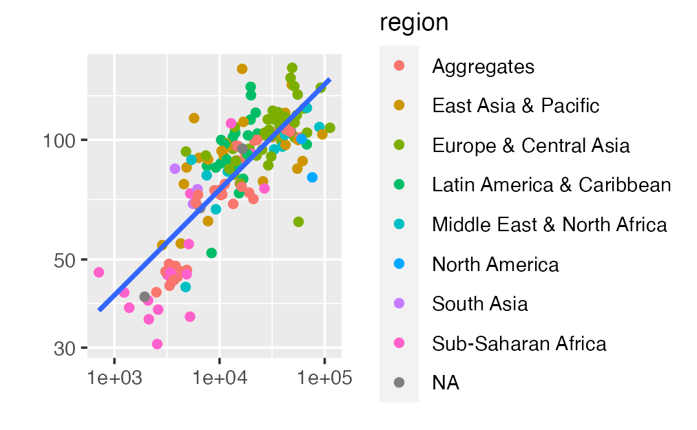

```r
df_yourdata |> filter(year == 2020) |>
  drop_na(short_name_2, short_name_1) |>
  ggplot(aes(short_name_2, short_name_1)) + geom_point(aes(col = region)) +
  geom_smooth(method = "lm", formula = 'y~x', se = FALSE) +
  scale_x_log10() + scale_y_log10() +
  labs(title = "",
       x = "",
       y = "")
```

**Observations and Questions:**

#### Summary of a linear model

Edit year if necessary.

```r
df_yourdata |> filter(year == 2020) |> drop_na(short_name_2, short_name_1) |>
  lm(log10(short_name_1)~log10(short_name_2), data = _) |> summary()
```

```
Call:
lm(formula = log10(short_name_1) ~ log10(short_name_2), data = drop_na(filter(df_yourdata,
    year == 2020), short_name_2, short_name_1))

Residuals:
      Min        1Q    Median        3Q       Max
-0.279981 -0.058887  0.003311  0.063366  0.246949

Coefficients:
                    Estimate Std. Error t value Pr(>|t|)
(Intercept)          0.81316    0.06423   12.66   <2e-16 ***
log10(short_name_2)  0.26533    0.01532   17.32   <2e-16 ***
---
Signif. codes:  0 ‘***’ 0.001 ‘**’ 0.01 ‘*’ 0.05 ‘.’ 0.1 ‘ ’ 1

Residual standard error: 0.08889 on 172 degrees of freedom
Multiple R-squared:  0.6356,    Adjusted R-squared:  0.6335
F-statistic: 300.1 on 1 and 172 DF,  p-value: < 2.2e-16
```

**Observations and Questions:**